# Exercise 4: Metagenomics - Oilspill Analysis

**Submit until Friday 22 December, 2017**

# Notice

This exercise is an [RMarkdown](http://rmarkdown.rstudio.com/) notebook composed of text and code which you can load into RStudio, run the code, record the output and fill in missing parts. This is a form of [literate programming](https://en.wikipedia.org/wiki/Literate_programming) which has gained much attention in science lately. Markdown syntax is simple text with additional syntax and the RStudio website has a [good reference card for RMarkdown](https://www.rstudio.com/resources/cheatsheets/). Before you submit your solution, make sure that your entire notebook runs through and generated corresponding output. You can then turn in your report as a generated HTML file together with your modified Rmd file. However, if you want, you can also follow the exercise manually and create your report in another program. Make sure to fill in your names below.

```
**Name: Yankun Xu**
**Name: Duygu Ayalp**
```

# Background

In this exercise we will analyze environmental metagenome data. The data comes from the study of [Mason et al. (2014)](https://doi.org/10.1038/ismej.2013.254) and derives from marine sediments taken to investigate in the [Deepwater horizon oilspill in the Mexican Gulf](https://en.wikipedia.org/wiki/Deepwater_Horizon_oil_spill) which had a severe impact on the ecosystem. Here is a summary of the samples is presented in the table below. Three samples were taken close to the oilspill well head, and three samples taken further away are used as control. We will use 16S sequences obtained by [amplicon sequencing](https://en.wikipedia.org/wiki/Amplicon) in the first part and and shotgun metagenomics sequences in the second part of this exercise sheet.

The samples where taken at different places around the wellhead and the contamination of the samples was measured in terms of polycyclic aromatic hydrocarbons (PAHs) and set as low or high contamination level.

| Sample ID | Group | Distance from wellhead (km) | Total PAH (g/kg) |
| --- | --- | --- | --- |
| BP278 | Highly contaminated | 2.7 | 6041.22 |
| BP315 | Highly contaminated | 0.5 | 5248.74 |
| BP331 | Highly contaminated | 0.3 | 2580.95 |
| BP101 | Less contaminated | 10.1 | 2.64 |
| BP155 | Less contaminated | 15.1 | 88.70 |
| BP186 | Less contaminated | 59.5 | 26.31 |

**Aims**

By analyzing the data we want to address the following questions:

- Which species/OTUs are present in the samples? (taxonomic profiling using the 16S gene)
- How does the species composition and diversity compare between samples?
- Which protein functions can be found in the different samples? (shotgun metagenomics)
- Which functions differ between polluted and clean environment?

# General

Here, we will run the entire analysis in R. Typically, for larger datasets command line program packages such as [QIIME](http://qiime.org/) and [mothur](https://www.mothur.org/) are used. The logic and workflow is comparable.

# Part 1 - 16S sequence data diversity and taxonomic composition

## Sequence variant clustering

We will use the R package [dada2](https://benjjneb.github.io/dada2/index.html) to denoise the 16S sequences. Denoising means to eliminate the sequence variation which is due to sequencing errors while trying to keep natural sequence variation representing for instance inter-species diversity.

You need to download the sequence data and unpack it in the working directory.

To start, we load the package `dada2` and create some auxilary vectors

```r
library(dada2)
sample_names <- c("BP101","BP155","BP186","BP278","BP315","BP331")
sample_files <- paste0(sample_names, "_16s.fq.gz")
```

The read sequences are already quality filtered and PCR primers, adapters and barcodes have been removed. Still, we will have a look at the quality values of the sequenced positions because these are used in the denoising procedure.

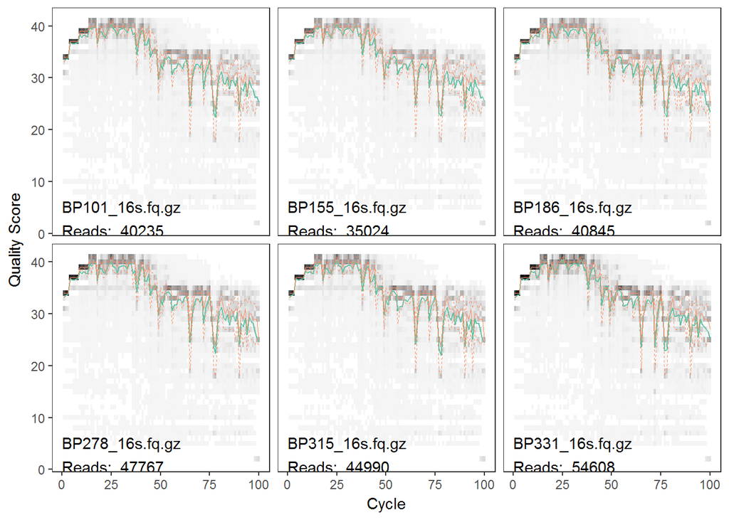

```r
plotQualityProfile(sample_files)
```

**Exercise 1: Why do you think does the quality of the Illumina reads drop towards the end (consult the help of the plotting function to understand the colors of the lines)?**

*In the grey-scale heat map for the quality score of samples, dark colors means higher frequency. Each plot has the similar features,dark colors hold in the beginning, and the color becomes lighter towards to the end.* *By the way, we could also check the green line which means the mean at the position, we will find that the green line is decreasing from the beginning towards to the end*

We start by collapsing identical sequences for each sample to save computation time and memory.

```r
reads_derep <- derepFastq(sample_files, verbose=TRUE)
```

```
## Dereplicating sequence entries in Fastq file: BP101_16s.fq.gz
```

```
## Encountered 15104 unique sequences from 40235 total sequences read.
```

```
## Dereplicating sequence entries in Fastq file: BP155_16s.fq.gz
```

```
## Encountered 13769 unique sequences from 35024 total sequences read.
```

```
## Dereplicating sequence entries in Fastq file: BP186_16s.fq.gz
```

```
## Encountered 19742 unique sequences from 40845 total sequences read.
```

```
## Dereplicating sequence entries in Fastq file: BP278_16s.fq.gz
```

```
## Encountered 15654 unique sequences from 47767 total sequences read.
```

```
## Dereplicating sequence entries in Fastq file: BP315_16s.fq.gz
```

```
## Encountered 12439 unique sequences from 44990 total sequences read.
```

```
## Dereplicating sequence entries in Fastq file: BP331_16s.fq.gz
```

```
## Encountered 11790 unique sequences from 54608 total sequences read.
```

**Exercise 2: How many sequences are in each sample and how redundant are these? Extract the number of unique sequences as a vector and report the them as fractions of the original read number**

```r
sample.len = length(sample_files)
num.unique = vector(mode ="double", length = sample.len)
num.unique[1] = length(reads_derep$BP101_16s.fq.gz$uniques)
num.unique[2] = length(reads_derep$BP155_16s.fq.gz$uniques)
num.unique[3] = length(reads_derep$BP186_16s.fq.gz$uniques)
num.unique[4] = length(reads_derep$BP278_16s.fq.gz$uniques)
num.unique[5] = length(reads_derep$BP315_16s.fq.gz$uniques)
num.unique[6] = length(reads_derep$BP331_16s.fq.gz$uniques)
num.unique.frac = vector(mode ="double", length = sample.len)
num.unique.frac[1] = num.unique[1] / 40235
num.unique.frac[2] = num.unique[2] / 35024
num.unique.frac[3] = num.unique[3] / 40845
num.unique.frac[4] = num.unique[4] / 47767
num.unique.frac[5] = num.unique[5] / 44990
num.unique.frac[6] = num.unique[6] / 54608
num.unique.frac
```

```
## [1] 0.3753946 0.3931304 0.4833395 0.3277158 0.2764837 0.2159024
```

Next, we will cluster (denoise) the 16S sequences so that each cluster represents a species variant or Operational Taxonomic Unit (OTU). Dada2 incorporates a sequence error model to distinguish noise from real sequence variation. The first step is to learn the model parameters from the read dataset and the second is the actual clustering. Finally, we construct a sequence count table after removing chimeras which are artifical hybrid sequences created during DNA amplification using PCR.

```r
error_reads <- learnErrors(reads_derep, multithread=TRUE)
```

```
## Initializing error rates to maximum possible estimate.
## Sample 1 - 40235 reads in 15104 unique sequences.
## Sample 2 - 35024 reads in 13769 unique sequences.
## Sample 3 - 40845 reads in 19742 unique sequences.
## Sample 4 - 47767 reads in 15654 unique sequences.
## Sample 5 - 44990 reads in 12439 unique sequences.
## Sample 6 - 54608 reads in 11790 unique sequences.
##    selfConsist step 2
##    selfConsist step 3
##    selfConsist step 4
##    selfConsist step 5
##    selfConsist step 6
## Convergence after  6  rounds.
## Total reads used:  263469
```

```r
cluster_reads <- dada(reads_derep, err=error_reads, multithread=TRUE)
```

```
## Sample 1 - 40235 reads in 15104 unique sequences.
## Sample 2 - 35024 reads in 13769 unique sequences.
## Sample 3 - 40845 reads in 19742 unique sequences.
## Sample 4 - 47767 reads in 15654 unique sequences.
## Sample 5 - 44990 reads in 12439 unique sequences.
## Sample 6 - 54608 reads in 11790 unique sequences.
```

```r
seqtab_reads <- removeBimeraDenovo(makeSequenceTable(cluster_reads), multithread=TRUE, verbose=TRUE)
```

```
## As of the 1.4 release, the default method changed to consensus (from pooled).
```

```
## Identified 124 bimeras out of 1829 input sequences.
```

**Exercise 3: Inspect the content of `seqtab_reads` and extract the number of inferred sequence variants per sample as a vector. Calculate the fraction of variant sequences both among unique sequences and the original sample size for each sample.**

```r
sam1.var = seqtab_reads[1,]
sam2.var = seqtab_reads[2,]
sam3.var = seqtab_reads[3,]
sam4.var = seqtab_reads[4,]
sam5.var = seqtab_reads[5,]
sam6.var = seqtab_reads[6,]

sam1.var = cbind(sam1.var, sam1.var/15104, sam1.var/40235)
colnames(sam1.var) = c("variants","var/unique","var/total")
sam2.var = cbind(sam2.var, sam2.var/13769, sam2.var/35024)
colnames(sam2.var) = c("variants","var/unique","var/total")
sam3.var = cbind(sam3.var, sam3.var/19742, sam3.var/40845)
colnames(sam3.var) = c("variants","var/unique","var/total")
sam4.var = cbind(sam4.var, sam4.var/15654, sam4.var/47767)
colnames(sam4.var) = c("variants","var/unique","var/total")
sam5.var = cbind(sam5.var, sam5.var/12439, sam5.var/44990)
colnames(sam5.var) = c("variants","var/unique","var/total")
sam6.var = cbind(sam6.var, sam6.var/11790, sam6.var/54608)
colnames(sam6.var) = c("variants","var/unique","var/total")
```

## Taxonomic annotation

Basically, we have reduced the heterogenous sequences and their qualities to a smaller set of 16S sequence variants and corresponding counts in `seqtab_reads`. In order to annotate assign these variants to taxa, we match them against a set of reference sequences with annotation in the file ‘greengenes_13.8_97.fna.gz’.

```r
taxa_reads <- assignTaxonomy(seqtab_reads, "greengenes_13.8_97.fna.gz", tryRC=TRUE)
```

## Plotting

Now we have everything read to start our analysis. We will use the [phyloseq R package](https://joey711.github.io/phyloseq/) for this.

```r
library(phyloseq)
library(ggplot2)
```

We need to load the metadata table which groups the samples into low and high contamination samples. We will also make sure that the samples are called the same in the otu and taxa tables. Finally, we convert bundle the information in a ‘phyloseq’ object.

```r
metadata <- read.delim("metadata.tsv")
rownames(metadata) <- metadata$ID
rownames(seqtab_reads) <- metadata$ID
ps_reads <- phyloseq(otu_table(seqtab_reads, taxa_are_rows=FALSE), sample_data(metadata), tax_table(taxa_reads))
```

First, we want to show the sample diversity for each of the samples. This so-called [alpha-diversity](https://en.wikipedia.org/wiki/Alpha_diversity) tells us how many distinct OTUs inhabit an ecosystem.

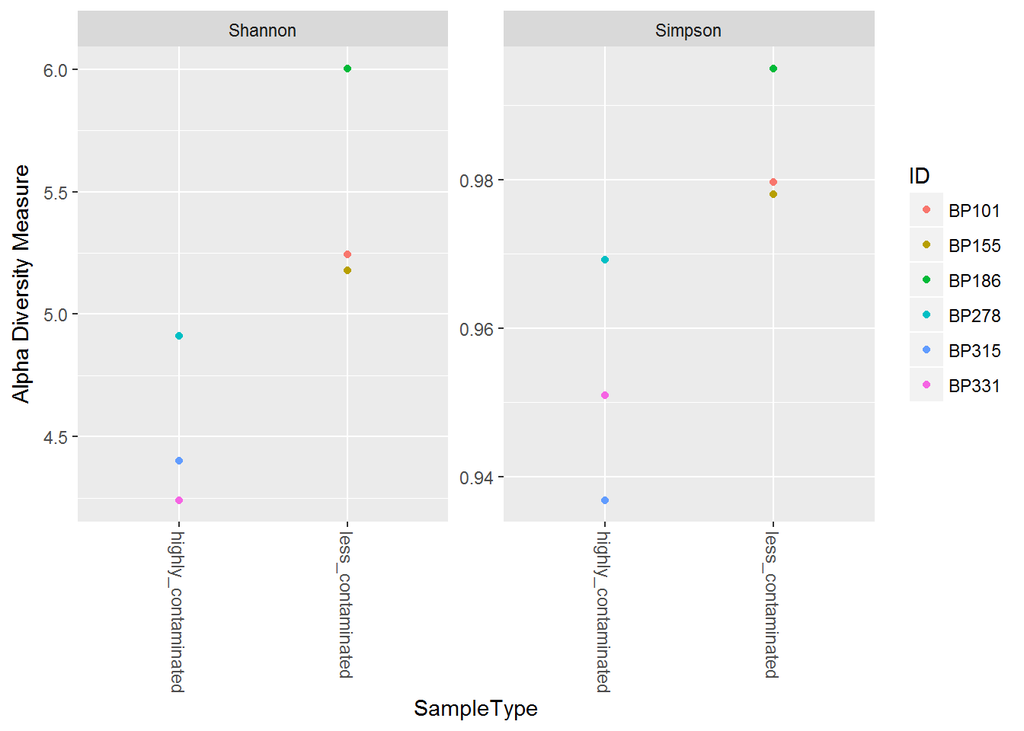

```r
plot_richness(ps_reads, x="SampleType", measures=c("Shannon", "Simpson"), col="ID")
```

**Exercise 4: Explain what you see and what Shannon and Simpson stand for.**

*Less and highly contaminated samples have the same number of richness(three). The plot shows that less and highly contaminated sample has significant differences in both shannon and simpson diversity index, and highly contaminated samples have less diversity than the less samples in both indexs. Shannon and Simpson both are sorts of diversity index, shannon means the shannon entropy, and simpson index was introduced to meausre the degree of concentration when individuals are classified into types*

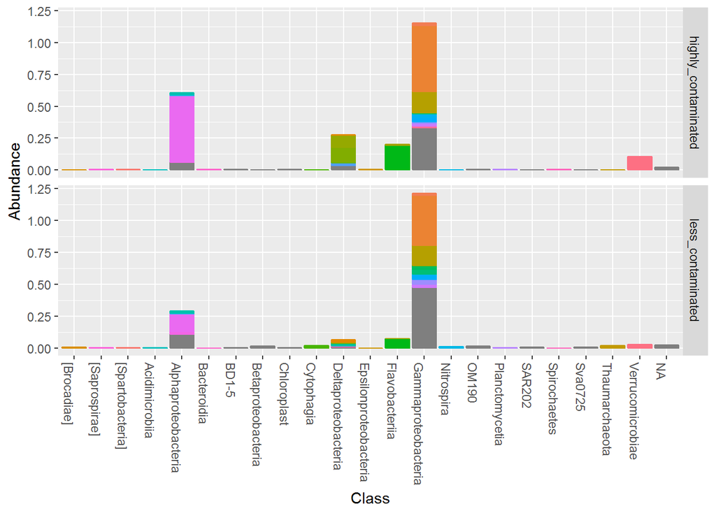

```r
ps_plot <- transform_sample_counts(ps_reads, function(x) x/sum(x))
ps_plot <- prune_taxa(names(sort(taxa_sums(ps_reads), decreasing=TRUE)[1:200]), ps_plot)
plot_bar(ps_plot, x="Class", facet_grid=SampleType~., fill="Family") + geom_bar(aes(color=Family, fill=Family), stat="identity", position="stack") + theme(legend.position="none")
```

**Exercise 5: Can you spot a difference? Formulate a hypothesis and try to validate it by plotting the same barplot but once per sample. Elaborate on whether you can confirm your hypothesis.**

*For some classes, there are significant diffences among them, such as Alpha-, Delta-,Gamma- proteobacteria and Flavobacteriia. One hypothesis is formulated that Alpha-proteobacteria has significant higher abundance in higher contaminated samples.*

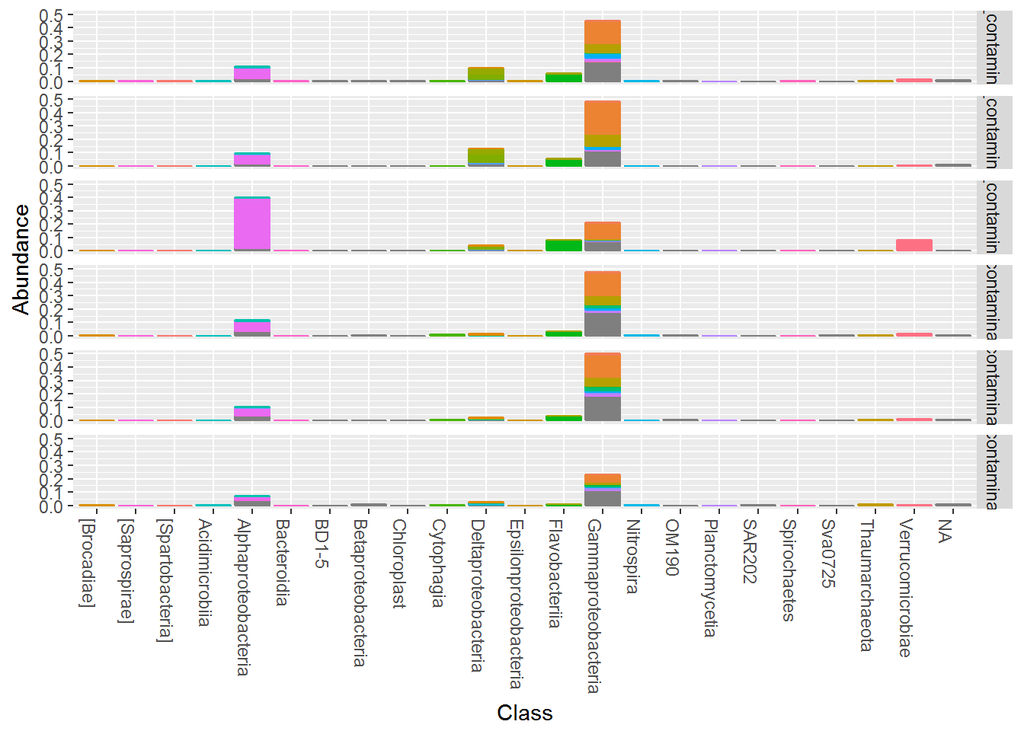

```r
plot_bar(ps_plot, x="Class", facet_grid=SampleName~., fill="Family") + geom_bar(aes(color=Family, fill=Family), stat="identity", position="stack") + theme(legend.position="none")
```

*We plot the barplot for each sample, we will see that Alpha-proteobacteria has similar abundance among all samples expect for highly_contaminated_3, our hypothesis is wrong, one single highly-contaminated dominated sample make us confused previously.*

Normalization of count data is a critical point in the analyis of changes of taxa and OTUs. To avoid inappropriate conclusions, it is better to use statistical models designed for count data so that normalization and subsampling is not needed. Here, we try do identify the OTUs that vary significantly in frequency between the two groups. We will use the the [DESeq2 R package](https://doi.org/10.18129/B9.bioc.DESeq2) for this task, which is also often used in the analysis of RNA and gene expression data. We run a Wald test for the count data in both groups which calculates the log-fold-change and significance (p-values), among other measures.

```r
library(DESeq2)
test_reads <- DESeq(phyloseq_to_deseq2(ps_reads, ~SampleType), test="Wald", fitType="parametric", parallel=TRUE)
head(results(test_reads))
```

```
## log2 fold change (MLE): SampleType less contaminated vs highly contaminated
## Wald test p-value: SampleType less contaminated vs highly contaminated
## DataFrame with 6 rows and 6 columns
##                                                                                                       baseMean
##                                                                                                      <numeric>
## TACGGAGGGTGCGAGCGTTAATCGGAATTACTGGGCGTAAAGCGCGCGTAGGCGGCCTGATAAGTTGGATGTGAAAGCCCTGGGCTCAACCTAGGAACTG 5596.9888
## TACGGAGGGGACTAGCGTTGTTCGGAATTACTGGGCGTAAAGCGTACGTAGGCGGATCAGAAAGTATGGGGTGAAATCCCAGGGCTCAACCCTGGAACTG 2280.8517
## TACGAGGGGTGCAAGCGTTAATCGGAATTACTGGGCGTAAAGCGTTCGTAGGCGGTTATTTAAGCAAGATGTGAAAGCCCAGGGCTCAACCTTGGAACTG 1032.4243
## TACGAAGGTCCCGAGCGTTATTCGGAATCACTGGGCGTAAAGAGTACGTAGGCGGTCAGGTAAGTCAGGTGTGAAATCCCGGAGCTCAACTCCGGAACTG  899.9650
## TACGGAGGGGGTTAGCGTTGTTCGGAATTACTGGGCGTAAAGCGCACGTAGGCGGACTGATCAGTTAGAGGTGAAATCCCAGGGCTCAACCCTGGAACTG  826.0020
## TACGAGGGGTGCAAGCGTTAATCGGAATTACTGGGCGTAAAGCGTTCGTAGGCGGTCTATTAAGCAAGATGTGAAAGCCCAGGGCTCAACCTTGGAACTG  580.2739
##                                                                                                      log2FoldChange
##                                                                                                           <numeric>
## TACGGAGGGTGCGAGCGTTAATCGGAATTACTGGGCGTAAAGCGCGCGTAGGCGGCCTGATAAGTTGGATGTGAAAGCCCTGGGCTCAACCTAGGAACTG      -1.336899
## TACGGAGGGGACTAGCGTTGTTCGGAATTACTGGGCGTAAAGCGTACGTAGGCGGATCAGAAAGTATGGGGTGAAATCCCAGGGCTCAACCCTGGAACTG      -3.084592
## TACGAGGGGTGCAAGCGTTAATCGGAATTACTGGGCGTAAAGCGTTCGTAGGCGGTTATTTAAGCAAGATGTGAAAGCCCAGGGCTCAACCTTGGAACTG     -13.447811
## TACGAAGGTCCCGAGCGTTATTCGGAATCACTGGGCGTAAAGAGTACGTAGGCGGTCAGGTAAGTCAGGTGTGAAATCCCGGAGCTCAACTCCGGAACTG      -3.176535
## TACGGAGGGGGTTAGCGTTGTTCGGAATTACTGGGCGTAAAGCGCACGTAGGCGGACTGATCAGTTAGAGGTGAAATCCCAGGGCTCAACCCTGGAACTG      -3.748962
## TACGAGGGGTGCAAGCGTTAATCGGAATTACTGGGCGTAAAGCGTTCGTAGGCGGTCTATTAAGCAAGATGTGAAAGCCCAGGGCTCAACCTTGGAACTG       2.585538
##                                                                                                          lfcSE
##                                                                                                      <numeric>
## TACGGAGGGTGCGAGCGTTAATCGGAATTACTGGGCGTAAAGCGCGCGTAGGCGGCCTGATAAGTTGGATGTGAAAGCCCTGGGCTCAACCTAGGAACTG  2.231278
## TACGGAGGGGACTAGCGTTGTTCGGAATTACTGGGCGTAAAGCGTACGTAGGCGGATCAGAAAGTATGGGGTGAAATCCCAGGGCTCAACCCTGGAACTG  2.321927
## TACGAGGGGTGCAAGCGTTAATCGGAATTACTGGGCGTAAAGCGTTCGTAGGCGGTTATTTAAGCAAGATGTGAAAGCCCAGGGCTCAACCTTGGAACTG  3.906814
## TACGAAGGTCCCGAGCGTTATTCGGAATCACTGGGCGTAAAGAGTACGTAGGCGGTCAGGTAAGTCAGGTGTGAAATCCCGGAGCTCAACTCCGGAACTG  2.370281
## TACGGAGGGGGTTAGCGTTGTTCGGAATTACTGGGCGTAAAGCGCACGTAGGCGGACTGATCAGTTAGAGGTGAAATCCCAGGGCTCAACCCTGGAACTG  2.346436
## TACGAGGGGTGCAAGCGTTAATCGGAATTACTGGGCGTAAAGCGTTCGTAGGCGGTCTATTAAGCAAGATGTGAAAGCCCAGGGCTCAACCTTGGAACTG  3.178608
##                                                                                                            stat
##                                                                                                       <numeric>
## TACGGAGGGTGCGAGCGTTAATCGGAATTACTGGGCGTAAAGCGCGCGTAGGCGGCCTGATAAGTTGGATGTGAAAGCCCTGGGCTCAACCTAGGAACTG -0.5991627
## TACGGAGGGGACTAGCGTTGTTCGGAATTACTGGGCGTAAAGCGTACGTAGGCGGATCAGAAAGTATGGGGTGAAATCCCAGGGCTCAACCCTGGAACTG -1.3284619
## TACGAGGGGTGCAAGCGTTAATCGGAATTACTGGGCGTAAAGCGTTCGTAGGCGGTTATTTAAGCAAGATGTGAAAGCCCAGGGCTCAACCTTGGAACTG -3.4421430
## TACGAAGGTCCCGAGCGTTATTCGGAATCACTGGGCGTAAAGAGTACGTAGGCGGTCAGGTAAGTCAGGTGTGAAATCCCGGAGCTCAACTCCGGAACTG -1.3401513
## TACGGAGGGGGTTAGCGTTGTTCGGAATTACTGGGCGTAAAGCGCACGTAGGCGGACTGATCAGTTAGAGGTGAAATCCCAGGGCTCAACCCTGGAACTG -1.5977259
## TACGAGGGGTGCAAGCGTTAATCGGAATTACTGGGCGTAAAGCGTTCGTAGGCGGTCTATTAAGCAAGATGTGAAAGCCCAGGGCTCAACCTTGGAACTG  0.8134183
##                                                                                                            pvalue
##                                                                                                         <numeric>
## TACGGAGGGTGCGAGCGTTAATCGGAATTACTGGGCGTAAAGCGCGCGTAGGCGGCCTGATAAGTTGGATGTGAAAGCCCTGGGCTCAACCTAGGAACTG 0.5490643779
## TACGGAGGGGACTAGCGTTGTTCGGAATTACTGGGCGTAAAGCGTACGTAGGCGGATCAGAAAGTATGGGGTGAAATCCCAGGGCTCAACCCTGGAACTG 0.1840255691
## TACGAGGGGTGCAAGCGTTAATCGGAATTACTGGGCGTAAAGCGTTCGTAGGCGGTTATTTAAGCAAGATGTGAAAGCCCAGGGCTCAACCTTGGAACTG 0.0005771252
## TACGAAGGTCCCGAGCGTTATTCGGAATCACTGGGCGTAAAGAGTACGTAGGCGGTCAGGTAAGTCAGGTGTGAAATCCCGGAGCTCAACTCCGGAACTG 0.1801961733
## TACGGAGGGGGTTAGCGTTGTTCGGAATTACTGGGCGTAAAGCGCACGTAGGCGGACTGATCAGTTAGAGGTGAAATCCCAGGGCTCAACCCTGGAACTG           NA
## TACGAGGGGTGCAAGCGTTAATCGGAATTACTGGGCGTAAAGCGTTCGTAGGCGGTCTATTAAGCAAGATGTGAAAGCCCAGGGCTCAACCTTGGAACTG 0.4159782874
##                                                                                                             padj
##                                                                                                        <numeric>
## TACGGAGGGTGCGAGCGTTAATCGGAATTACTGGGCGTAAAGCGCGCGTAGGCGGCCTGATAAGTTGGATGTGAAAGCCCTGGGCTCAACCTAGGAACTG 0.670516406
## TACGGAGGGGACTAGCGTTGTTCGGAATTACTGGGCGTAAAGCGTACGTAGGCGGATCAGAAAGTATGGGGTGAAATCCCAGGGCTCAACCCTGGAACTG 0.277083954
## TACGAGGGGTGCAAGCGTTAATCGGAATTACTGGGCGTAAAGCGTTCGTAGGCGGTTATTTAAGCAAGATGTGAAAGCCCAGGGCTCAACCTTGGAACTG 0.002858657
## TACGAAGGTCCCGAGCGTTATTCGGAATCACTGGGCGTAAAGAGTACGTAGGCGGTCAGGTAAGTCAGGTGTGAAATCCCGGAGCTCAACTCCGGAACTG 0.272868491
## TACGGAGGGGGTTAGCGTTGTTCGGAATTACTGGGCGTAAAGCGCACGTAGGCGGACTGATCAGTTAGAGGTGAAATCCCAGGGCTCAACCCTGGAACTG          NA
## TACGAGGGGTGCAAGCGTTAATCGGAATTACTGGGCGTAAAGCGTTCGTAGGCGGTCTATTAAGCAAGATGTGAAAGCCCAGGGCTCAACCTTGGAACTG 0.543025843
```

We retrieve the results of the test and create an object for plotting. We add all the information needed to layout the plot. The plotting code looks complicated but is needed to format and sort the axes and to color the plot.

```r
results_reads <- results(test_reads, contrast=list("SampleType_less_contaminated_vs_highly_contaminated"))
sigtab_reads <- cbind(as(results_reads, "data.frame"), as(tax_table(ps_reads)[rownames(results_reads),], "matrix"))
class_ordering <- sort(tapply(sigtab_reads$log2FoldChange, sigtab_reads$Class, function(x) max(x)), decreasing=TRUE)  # sort class by max fold change
sigtab_reads$Class <- factor(as.character(sigtab_reads$Class), levels=names(class_ordering))  # order the x-axis
genus_ordering <- sort(tapply(sigtab_reads$log2FoldChange, sigtab_reads$Genus, function(x) max(x)), decreasing=TRUE)  # sort genus by max fold change
sigtab_reads$Genus <- factor(as.character(sigtab_reads$Genus), levels=names(genus_ordering))  # order ???
size <- apply(otu_table(ps_reads), 2, mean)
sigtab_reads$Size <- 50*(size/sum(size))^0.4
```

We subset the OTUs by selecting only those which have an adjusted p-value less than 1% and plot the results of the test. Note that by default, ’DESeq2` performs a conservative outlier filtering to reduce false positives.

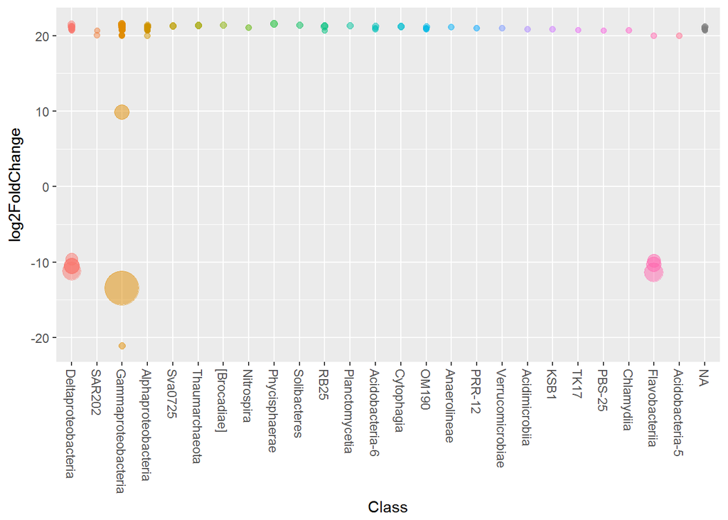

```r
sigtab_reads_plot <- sigtab_reads[which(sigtab_reads$padj < 0.01),]
ggplot(sigtab_reads_plot, aes(x=Class, y=log2FoldChange, color=Class)) + geom_point(size=sigtab_reads_plot$Size, alpha=0.5) + theme(axis.text.x=element_text(angle=-90, hjust=0, vjust=0.5), legend.position="none")
```

**Exercise 6: What conclusions do you draw from this plot and the previous abundance and diversity plots. Do they agree? (Note: the log foldchanges is positive if the OTU is abundant in the less contaminated samples and negative, if it is abundant in the contaminated samples). Characterize the OTUs which are significantly enrichted in the contaminated samples, for instance what are their lowest taxonomic annotations?**

*Firstly, we focus on the abundance. Based on this plot here, three OTU:Delta-,Gamma- proteobacteria and Falvobacteria is significantly abundant in the highly-contaminated samples, and even the wrong hypothesis we made in the last exercise, Alpha-proteobacteria is not abundant in the highly-contaminated samples, these conclusion is consistent with abundance plot. Secondly, for the diversity, we could find there are so many other OTUs abundant in the less-contaminated samples, which is consistent with the conclusion from diversity plots. By the way, The size of circle means the size(mean) of each OTU.*

*In the contaminated samples, Deltaproteobacteria class is the most frequent(three) abundant OTU from the plot, then we look into the data ‘sigtab_reads_plot’, we can get their available the lowest taxonomic annotations are Desulfocapsa and Pelobacteraceae.*

# Part 2 - Shotgun metagenomics

In the second part of this exercise sheet, the data we analyze are whole genome shotgun sequences instead of partial 16S gene sequences. This means, that they derive from any part of any genome in the corresponding environments. The sequenced reads are paired end Illumina sequences. We will perform the following data analysis:

1. Visual analysis of an alignment of the sequences to an assembled metagenome
2. Annotation with taxon and gene GFF files
3. Calculation of gene abundance values
4. Gene differential abundance analysis

In the last step, we will use the same methods as for the 16S differential OTU count analysis but at the gene level to find genes which are significantly enriched or depleted under the two different contamination levels.

## Loading data files

We start working with a small subset of the data. The reads were assembled into contigs which can be found in the FASTA file `contigs.fna`. The file `contigs.tsv` contains the name and the length of each contig. For each of the six samples, the reads where aligned to the contigs using bowtie2 and the alignments can be found the the corresponding files `BPXXX.bam`. Finally, we compared the contigs to reference collections to derive gene annotation using TIGRFAM and taxonomic annotation using the best BLAST hit. These annotations can be found in the files `contigs_genes.gff3` and `contigs_taxa.gff3`.

### Coverage annotation plot

We need to import some special packages. If they are not installed, you need to install them using the RStudio GUI or ’install.packages()`.

```r
library(GenomicRanges)
library(GenomicAlignments)
library(rtracklayer)
library(ggbio)
```

We start by reading the data files into R.

```r
contigs.meta <- read.delim("contigs.tsv", header=FALSE)
contigs.seqinfo <- Seqinfo(seqnames=as.vector(contigs.meta[,1]), seqlengths=contigs.meta[,2], genome="contigs")
contigs.ranges <- GRanges(seqnames=seqnames(contigs.seqinfo), strand="*", ranges = IRanges(start=1, width=seqlengths(contigs.seqinfo)), seqinfo=contigs.seqinfo)
genes.ranges <- GRanges(readGFF("contigs_genes.gff3", version=3), seqinfo=contigs.seqinfo)
taxa.ranges <- GRanges(readGFF("contigs_taxa.gff3", version=3), seqinfo=contigs.seqinfo)
sample1 <- coverage(readGAlignments("BP101.bam"))
sample2 <- coverage(readGAlignments("BP155.bam"))
sample3 <- coverage(readGAlignments("BP186.bam"))
sample4 <- coverage(readGAlignments("BP278.bam"))
sample5 <- coverage(readGAlignments("BP315.bam"))
sample6 <- coverage(readGAlignments("BP331.bam"))
```

And we create a circular plot with different tracks using the package `ggbio`. The tracks represent the following different sequence features (from inner to outer):

1. The positional read coverage over in each of the contigs in each of the six samples
2. The taxonomic annotation of subsequences based on the closest hit in a reference sequence collection
3. The gene annotation using [TIGRFAM gene families](https://en.wikipedia.org/wiki/TIGRFAMs).

[output not shown]

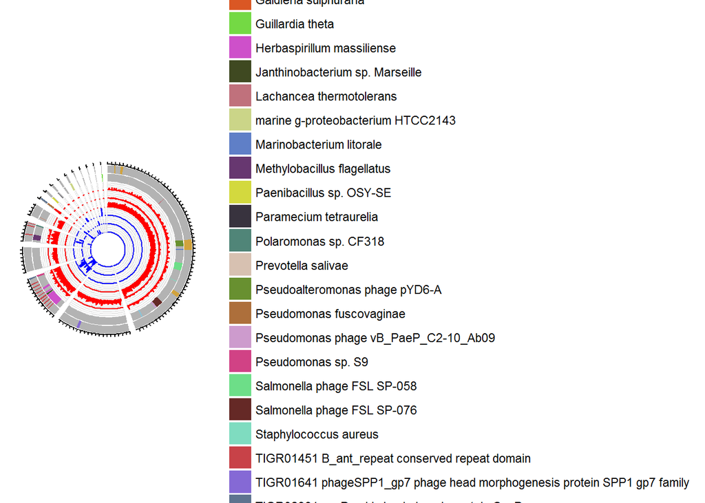

```r
colors <- c("#89C5DA", "#DA5724", "#74D944", "#CE50CA", "#3F4921", "#C0717C", "#CBD588", "#5F7FC7",  "#673770", "#D3D93E", "#38333E", "#508578", "#D7C1B1", "#689030", "#AD6F3B", "#CD9BCD", "#D14285", "#6DDE88", "#652926", "#7FDCC0", "#C84248", "#8569D5", "#5E738F", "#D1A33D", "#8A7C64", "#599861")  # custom color palette

ggbio() +
circle(GRanges(sample1), aes(y=score), geom="bar", fill="blue", col="blue", grid=TRUE, grid.background="gray90", radius=10) +
circle(GRanges(sample2), aes(y=score), geom="bar", fill="blue", col="blue", grid=TRUE, grid.background="gray90", radius=15) +
circle(GRanges(sample3), aes(y=score), geom="bar", fill="blue", col="blue", grid=TRUE, grid.background="gray90", radius=20) +
circle(GRanges(sample4), aes(y=score), geom="bar", fill="red", col="red", grid=TRUE, grid.background="gray90", radius=25) +
circle(GRanges(sample5), aes(y=score), geom="bar", fill="red", col="red", grid=TRUE, grid.background="gray90", radius=30) +
circle(GRanges(sample6), aes(y=score), geom="bar", fill="red", col="red", grid=TRUE, grid.background="gray90", radius=35) +
circle(contigs.ranges, fill="gray70", geom="rect", col=NA, radius=40) +
circle(taxa.ranges, aes(fill=rtaxname), geom="rect", col=NA, radius=40) +
circle(contigs.ranges, fill="gray70", geom="rect", col=NA, radius=45) +
circle(genes.ranges, aes(fill=ID), geom="rect", col=NA, radius=45) +
circle(contigs.ranges, geom="scale", scale.unit=100, col=NA, trackWidth=2, radius=50) +
scale_fill_manual(values=colors, name=NULL) + guides(fill=guide_legend(ncol=1)) + theme(legend.position="right")
```

**Exercise 7: Try to understand the plot. How long are the longest and the shortest contigs in the set? Based on what you see in the plot, what can you say about the possible origin of the longest contig?**

*The longest constig has range 31464, while the shortest contig has 97. We can see that the longest contig includes many taxas, such as ‘Salmonella phage FSL SP-058’, ‘Pseudoalteromonas phage pYD6-A’, ‘Marinobacterium litorale’, etc. After checking these taxs, we think its possible origin is bacterium.*

### Coverage calculation

We extract the gene positions and names and put them into a dataframe. We also define a function to extract the read coverage of a contig as a plain vector.

```r
genes.positions <- cbind(as.vector(seqnames(genes.ranges)), as.data.frame(ranges(genes.ranges)))  # extract data
colnames(genes.positions)[1] <- "id"
vectorize.coverage <- function(x) as.vector(x[[1]])  # turns contig into coverage vector
```

**Exercise 8: Calculate the mean read coverage of the first (longest) six contigs in the sixth sample using the `vectorize.coverage` function (compare with the circular plot to validate).**

```r
sample6.read.mean.1st = mean(vectorize.coverage(sample6[1]))
sample6.read.mean.2nd = mean(vectorize.coverage(sample6[3]))
sample6.read.mean.3rd = mean(vectorize.coverage(sample6[5]))
sample6.read.mean.4th = mean(vectorize.coverage(sample6[7]))
sample6.read.mean.5th = mean(vectorize.coverage(sample6[8]))
sample6.read.mean.6th = mean(vectorize.coverage(sample6[9]))

# sample6 doesn't include 2nd. 4th. 6th longest contigs from metadata. And the result we get is consistent with the circular plot.
```

Now, here is a function to calculate the mean coverage of a gene region over all samples.

```r
samples <- list(sample1, sample2, sample3, sample4, sample5, sample6)  # list of samples
gene.abundances <- function(name, start, stop) sapply(samples, function(x) mean(vectorize.coverage(x[name])[start:stop]))  # gene abundace in each sample
```

**Exercise 9: Write a function to calculate the mean read coverage of every gene in every sample using the dataframe `genes.positions` and the function `gene.abundances`. Each row should correspond to a gene and each column should correspond to a sample. Remember, that you can use `apply()` to achieve this. Don’t forget to output the table below.**

```r
gene.sample.table = matrix(0,20,6)
for (i in 1:20) {
  gene.sample.table[i,] = gene.abundances(genes.positions[i,1],genes.positions[i,2],genes.positions[i,3])
}

colnames(gene.sample.table) = c("sample1", "sample2", "sample3", "sample4", "sample5", "sample6")
rownames(gene.sample.table) = genes.positions[,1]
gene.sample.table
```

```
##                                  sample1   sample2 sample3    sample4
## NODE_3_length_5990_cov_9.21884 0.0000000 0.0000000       0   2.532663
## NODE_3_length_5990_cov_9.21884 0.0000000 0.0000000       0   2.669231
## NODE_3_length_5990_cov_9.21884 0.0000000 2.2661290       0   1.532258
## NODE_3_length_5990_cov_9.21884 0.0000000 2.3823529       0   1.838235
## NODE_3_length_5990_cov_9.21884 0.0000000 1.0529801       0   4.807947
## NODE_3_length_5990_cov_9.21884 0.2419355 0.0000000       0   1.725806
## NODE_3_length_5990_cov_9.21884 0.0000000 0.0000000       0   2.112903
## NODE_3_length_5990_cov_9.21884 0.3625000 0.0062500       0   1.262500
## NODE_3_length_5990_cov_9.21884 0.0000000 0.7851240       0   2.702479
## NODE_3_length_5990_cov_9.21884 0.0000000 0.0000000       0   3.816514
## NODE_3_length_5990_cov_9.21884 0.0000000 1.3931034       0   2.393103
## NODE_7_length_318_cov_6.78008  1.9195980 0.8291457       0  11.487437
## NODE_5_length_2659_cov_8.84857 0.0000000 1.4390244       0   6.768293
## NODE_5_length_2659_cov_8.84857 0.0000000 0.0000000       0   2.633803
## NODE_5_length_2659_cov_8.84857 0.0000000 0.0000000       0   4.382166
## NODE_1_length_31464_cov_25.774 0.0000000 0.0000000       0  99.044118
## NODE_1_length_31464_cov_25.774 0.0000000 0.0000000       0 105.371831
## NODE_1_length_31464_cov_25.774 0.0000000 0.0000000       0 117.374417
## NODE_1_length_31464_cov_25.774 0.0000000 0.0000000       0 114.906977
## NODE_2_length_9736_cov_5.54146 0.0000000 0.0000000       0   0.000000
##                                  sample5     sample6
## NODE_3_length_5990_cov_9.21884 40.753769  2.54271357
## NODE_3_length_5990_cov_9.21884 30.653846  5.89230769
## NODE_3_length_5990_cov_9.21884 42.911290  4.39516129
## NODE_3_length_5990_cov_9.21884 34.573529  2.34558824
## NODE_3_length_5990_cov_9.21884 36.264901  2.18543046
## NODE_3_length_5990_cov_9.21884 35.419355  0.02419355
## NODE_3_length_5990_cov_9.21884 46.161290  1.90322581
## NODE_3_length_5990_cov_9.21884 38.487500  6.07500000
## NODE_3_length_5990_cov_9.21884 48.181818  2.35537190
## NODE_3_length_5990_cov_9.21884 39.651376  0.79816514
## NODE_3_length_5990_cov_9.21884 27.731034  2.46896552
## NODE_7_length_318_cov_6.78008  11.623116 11.77889447
## NODE_5_length_2659_cov_8.84857 45.597561  5.62195122
## NODE_5_length_2659_cov_8.84857 32.183099  1.53521127
## NODE_5_length_2659_cov_8.84857 46.700637  2.90445860
## NODE_1_length_31464_cov_25.774  3.470588  0.00000000
## NODE_1_length_31464_cov_25.774  2.307042  1.42253521
## NODE_1_length_31464_cov_25.774  5.161226  1.56362425
## NODE_1_length_31464_cov_25.774  4.529517  0.72271914
## NODE_2_length_9736_cov_5.54146 30.157100  0.00000000
```